# Understanding Bayesian Credible Intervals

Mike Dehn

10/13/2021

# Introduction

In this tutorial, we will explore the idea of Bayesian credible intervals. For complete context, we begin with an introduction to both the frequentist and Bayesian approaches to statistical thinking. We further consider the concept of confidence and credible intervals in each approach. Once this conceptual foundation is established, we will walk through an example of applying these concepts to real world data.

## Frequentist vs. Bayesian Statistical Inference

Assume that there is a parameter, $\phi$, that we would like to estimate for a population. As an example, you might consider the average Body Mass Index (BMI) of adult males in the United States. While the United States has a robust medical system and plentiful medical data, it is impossible to collect all of this information for every person in the country. There are privacy concerns associated with medical data, and not every person has access to medical professionals. Clearly, we cannot know the value of $\phi$ with absolute certainty in this example; we must estimate $\phi$ based on the data available to us. **Statistical inference** is a process that allows us to build these estimates based on the data we have about a given population.

There are two primary approaches to statistical inference: **frequentist** and **Bayesian**. In frequentist statistics, samples from a population are used to estimate the value of $\phi$, but we do not assume that parameter is a random variable. Instead, we assume that $\phi$ has a fixed but unknown value that is not stochastic in nature. A frequentist might say, “the probability that the average BMI of adult males in the United States is 20.0 is either 0% or 100%, I just don’t know which one is correct.”

Conversely, in Bayesian statistics, $\phi$ is assumed to be a random variable. A Bayesian statistician might say, “the probability that the average BMI of adult males in the United States is 20.0 is $X%$, based on what we know from the data available to us.” The Bayesian statistician can provide a more precise estimate of the probability of a particular value for $\phi$, while the frequentist cannot. Note that this does not necessarily imply that the Bayesian is more accurate!

NOTE: If further explanation is helpful, there is an excellent article and video on the Towards Data Science website that provides an intuitive explanation of the differences between Bayesian and frequentist statistics: https://towardsdatascience.com/statistics-are-you-bayesian-or-frequentist-4943f953f21b

Both forms of statistical inference are rife with uncertainty. We do not *know* the true value of $\phi$ based on statistical procedures; all we have is an *estimate* with an established level of uncertainty. In frequentist statistics, this uncertainty is described using **confidence intervals**. Bayesian statistics uses the related, but different, **credible interval**.

### Frequentist Confidence Intervals

The frequentist notion of confidence intervals is generally well-known in most communities with some degree of statistical sophistication, but are often misunderstood. Each confidence interval is calculated according to the desired **confidence level** is perhaps the most confusing. Misinterpretation of the confidence level is primarily responsible for much of the confusion around confidence intervals. A common misconception is that a confidence interval is a range of values that contain $\phi$ with a probability equal to the confidence level. In other words, if the 95% confidence interval for $\phi$ is such that $\phi \in (25, 35)$, it is tempting, but incorrect, to assert that $P(\phi \in (25,35)) = 0.95$.

You may be asking, “why isn’t this true?”

As explained in the previous section of this tutorial, frequentist statistics does not assign probabilities to parameter estimates - frequentists assume that the *true* value of $\phi$ is not a random variable, rather it is an unknown non-stochastic value.

What, then, does a confidence level signify? The definition is not straightforward: “a confidence level represents the theoretical long-run frequency (i.e., the proportion) of confidence intervals that contain the true value of the unknown population parameter.” (“Confidence Intervals” 2021)

In practical terms, this definition says: Let’s imagine we can run the same experiment over and over again. If you do, in the long-run, you’ll find that the percentage of confidence intervals that contain $\phi$ tends toward the confidence level percentage we selected. For a 90% confidence level, 90% of confidence intervals derived from repeats of this experiment will contain the true value of $\phi$.

If this doesn’t feel super satisfying to you, you aren’t alone. The frequentist confidence interval sidesteps assigning a probability to the true value of $\phi$ in favor of making an assertion about the confidence we can have in the result of the experiment itself.

### Bayesian Credible Intervals

So, is there a way to establish the more intuitive notion of a probability estimate for the value of $\phi$ itself within an interval? If you are a Bayesian statistician, the answer is “yes.”

Bayesian inference uses the notion of credible intervals to assign a probability that the estimated parameter $\phi$ lies within an established range. When we calculate the 95% credible interval for a sample, we assert that the probability of the true value of $\phi$ resides in the given interval is 95%, given the data available to us. (“Credible Intervals” 2021)

This definition speaks to many peoples’ intuition about what an estimate interval *ought* to be. It maps well to our understanding of probability as an estimation of what we think is true, while providing an objective accounting for our uncertainty in the estimate.

Although credible intervals are more intuitively understood than their frequentist counterparts, they do have some undesirable characteristics. For example, they require us to construct a posterior distribution, which can be computationally expensive.

# Learning by Example with Real World Data

With this foundation, let us continue with a concrete example of calculating a credible interval for a data set in R. In this example, we will use a data set collected by the United States Center for Disease Control (CDC) as part of their National Health and Nutrition Examination Survey for calendar years 2017-2018. Using these data, we will establish a credible interval for the average BMI of adult males in the United States. (“NHANES 2017-2018” 2021)

One advantage to using this data set and estimating the mean BMI parameter is that it is a well-studied parameter within the healthcare community. Therefore, we can establish some intuition as to the accuracy of our result.

## Prerequisites

Make sure you have R installed on your workstation, as well as the following packages:

- `tidyverse`
- `haven`
- `dplyr`
- `ggplot2`
- `bayestestR`

All of these packages can be installed from the R console using the `install.packages` command.

## Ingesting Data

The data set can be downloaded from the CDC’s website. There are two files that we need to download:

- Body measures - https://wwwn.cdc.gov/Nchs/Nhanes/2017-2018/P_BMX.XPT
- Demographics - https://wwwn.cdc.gov/Nchs/Nhanes/2017-2018/P_DEMO.XPT

The body measures data contains height, weight, BMI, and related metrics for each participant in the survey. The demographics data provides various biographical data for each participant, which we will use to filter only for adult males. According to the CDC’s website, the data set considers “adults” to be age 20 or higher at the time of their measurements.

We can programmatically download the data set from the CDC’s website using the code below. If this snippet does not work for you, try downloading the data manually.

```r
curl::curl_download('https://wwwn.cdc.gov/Nchs/Nhanes/2017-2018/P_BMX.XPT',
                    'body_measures.xpt')

curl::curl_download('https://wwwn.cdc.gov/Nchs/Nhanes/2017-2018/P_DEMO.XPT',
                    'demographics.xpt')
```

You should now have two files in your working directory - `body_measures.xpt` and `demographics.xpt`. The data are in a non-human readable data format, but they can be ingested using the `haven` R package.

```r
library(tidyverse)
library(haven)
body_measures <- read_xpt('body_measures.xpt')
demographics <- read_xpt('demographics.xpt')
```

Now that we have ingested the body measures data set, we should check that the results make sense. Let’s take a look at a summary of the data set.

```r
summary(body_measures)
```

```
##       SEQN           BMDSTATS         BMXWT            BMIWT
##  Min.   :109263   Min.   :1.000   Min.   :  3.20   Min.   :1.000
##  1st Qu.:113171   1st Qu.:1.000   1st Qu.: 42.30   1st Qu.:3.000
##  Median :117082   Median :1.000   Median : 68.10   Median :3.000
##  Mean   :117069   Mean   :1.135   Mean   : 65.43   Mean   :2.993
##  3rd Qu.:120974   3rd Qu.:1.000   3rd Qu.: 86.30   3rd Qu.:3.000
##  Max.   :124822   Max.   :4.000   Max.   :254.30   Max.   :4.000
##                                   NA's   :225      NA's   :13712
##     BMXRECUM         BMIRECUM        BMXHEAD         BMIHEAD
##  Min.   : 49.10   Min.   :1       Min.   :32.40   Min.   : NA
##  1st Qu.: 70.10   1st Qu.:1       1st Qu.:39.20   1st Qu.: NA
##  Median : 82.95   Median :1       Median :41.30   Median : NA
##  Mean   : 81.51   Mean   :1       Mean   :41.12   Mean   :NaN
##  3rd Qu.: 92.88   3rd Qu.:1       3rd Qu.:42.98   3rd Qu.: NA
##  Max.   :113.90   Max.   :1       Max.   :48.30   Max.   : NA
##  NA's   :12830    NA's   :14257   NA's   :13990   NA's   :14300
##      BMXHT           BMIHT           BMXBMI         BMDBMIC         BMXLEG
##  Min.   : 78.3   Min.   :1.000   Min.   :11.90   Min.   :1.00   Min.   :24.80
##  1st Qu.:151.1   1st Qu.:1.000   1st Qu.:20.40   1st Qu.:2.00   1st Qu.:36.00
##  Median :162.1   Median :3.000   Median :25.80   Median :2.00   Median :38.90
##  Mean   :156.5   Mean   :2.181   Mean   :26.66   Mean   :2.55   Mean   :38.75
##  3rd Qu.:171.3   3rd Qu.:3.000   3rd Qu.:31.40   3rd Qu.:3.00   3rd Qu.:41.50
##  Max.   :199.6   Max.   :3.000   Max.   :92.30   Max.   :4.00   Max.   :55.00
##  NA's   :1143    NA's   :14129   NA's   :1163    NA's   :9551   NA's   :3316
##      BMILEG         BMXARML        BMIARML         BMXARMC         BMIARMC
##  Min.   :1       Min.   : 9.4   Min.   :1       Min.   :11.20   Min.   :1
##  1st Qu.:1       1st Qu.:31.9   1st Qu.:1       1st Qu.:23.60   1st Qu.:1
##  Median :1       Median :36.0   Median :1       Median :30.30   Median :1
##  Mean   :1       Mean   :33.8   Mean   :1       Mean   :29.32   Mean   :1
##  3rd Qu.:1       3rd Qu.:38.6   3rd Qu.:1       3rd Qu.:34.90   3rd Qu.:1
##  Max.   :1       Max.   :49.9   Max.   :1       Max.   :64.50   Max.   :1
##  NA's   :13812   NA's   :810    NA's   :13813   NA's   :816     NA's   :13807
##     BMXWAIST         BMIWAIST         BMXHIP          BMIHIP
##  Min.   : 40.00   Min.   :1       Min.   : 62.5   Min.   :1
##  1st Qu.: 73.30   1st Qu.:1       1st Qu.: 95.5   1st Qu.:1
##  Median : 91.00   Median :1       Median :103.4   Median :1
##  Mean   : 89.67   Mean   :1       Mean   :105.7   Mean   :1
##  3rd Qu.:105.40   3rd Qu.:1       3rd Qu.:113.3   3rd Qu.:1
##  Max.   :187.50   Max.   :1       Max.   :187.5   Max.   :1
##  NA's   :1726     NA's   :13683   NA's   :4438    NA's   :13924
```

The most important variable in this data set is the `BMXBMI` variable, which corresponds to the BMI calculated for each individual under observation in the survey. We can see that there are 1,163 rows containing `NA` values for this variable. In our calculations, we will simply reject any rows containing `NA` for the BMXBMI variable, but it is important for us to remember this in the context of describing any uncertainty in our final result.

The code snippet below will perform this cleaning for us.

```r
library(dplyr)
body_measures_clean <- filter(body_measures, ! is.na(BMXBMI))
```

We no longer have any `NA` values in the BMI field, so we have rejected any samples that may be problematic for our parameter estimation. However, we have not yet selected for the specific population of interest: 20+ year old males.

To select on this particular subset of the population, we can join the `body_measures` and `demographics` data set on their common column `SEQN` that uniquely identifies a participant. We then filter any rows do not satisfy the criteria of being males of age 20 or greater.

```r
attributed_data <- merge(body_measures_clean, demographics, by = 'SEQN')
adult_male_data <- filter(attributed_data, RIAGENDR == 1, RIDAGEYR >= 20)
```

This gives us a data set limited only to adult males in the United States. The data set has been reduced from its original size of around 13,137 to 4,051 samples, but we have eliminated groups that may make our results harder to interpret.

Using the code snippet below, we plot the posterior distribution of these data.

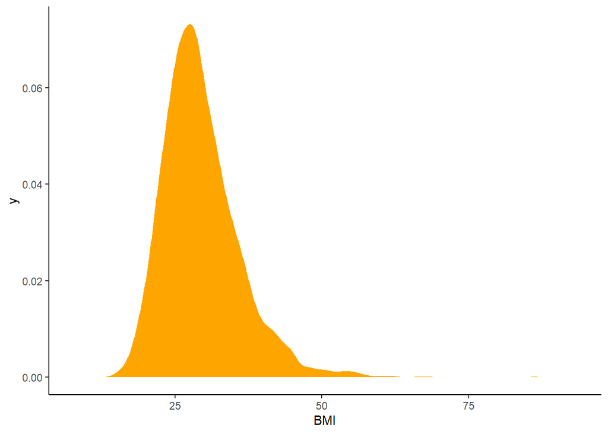

```r
library(bayestestR)

posterior <- adult_male_data$BMXBMI

posterior_dist <- posterior %>%
  estimate_density(extend=TRUE)

posterior_dist %>%
  ggplot(aes(x = x, y = y)) +
  geom_area(fill = "orange") +
  theme_classic() +
  xlab("BMI")
```

## Calculating Credible Interval

We will use the `bayestestR` package to calculate the credible interval for our data set. Credible intervals can be calculated using several approaches. In this tutorial, we will calculate credible intervals using two methods: highest density interval (HDI) and equal-tailed interval (ETI).

The HDI approach centers the credible interval around the highest density region of the posterior distribution. This means that all possible values for the estimated parameter $\phi$ have the lower probability outside of the interval than inside.

The ETI approach ensures that the area of the posterior distribution outside the credible interval (i.e., the tails) are equal. In skewed distributions, this may cause the probability of parameter values inside the credible interval to be lower than some values outside the interval, which is not typically desirable.

We use the code snippet below to generate both HDI and ETI credible intervals for the CDC data set.

```r
(ci_hdi <- ci(adult_male_data$BMXBMI, method = "HDI", ci = 0.89))
```

```
## 89% HDI: [19.30, 38.30]
```

```r
(ci_eti <- ci(adult_male_data$BMXBMI, method = "ETI", ci = 0.89))
```

```
## 89% ETI: [20.90, 41.00]
```

As we can see from the results above, the credible interval values are slightly different between the HDI and ETI approaches, with the ETI skewing higher due to significant outliers to the right of the posterior distribution. This is illustrated in the figure below, where the blue lines bound the HDI credible interval, and the red lines bound the ETI credible interval.

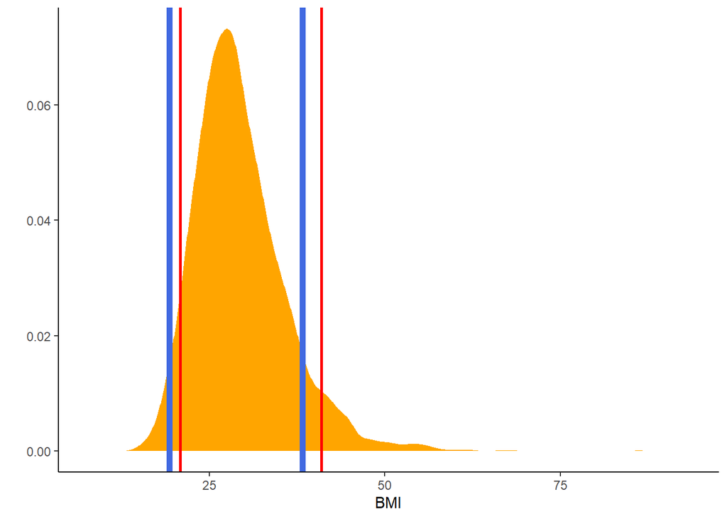

```r
posterior_dist %>%
  ggplot(aes(x = x, y = y)) +
  geom_area(fill = "orange") +
  theme_classic() +
  # HDI in blue
  geom_vline(xintercept = ci_hdi$CI_low, color = "royalblue", size = 2) +
  geom_vline(xintercept = ci_hdi$CI_high, color = "royalblue", size = 2) +
  # Quantile in red
  geom_vline(xintercept = ci_eti$CI_low, color = "red", size = 1) +
  geom_vline(xintercept = ci_eti$CI_high, color = "red", size = 1) +
  xlab("BMI") +
  ylab("")
```

From these results, we can infer that the true mean BMI lies within these confidence intervals with probability 0.89. In other words:

- $0.89 \text{ HDI} \rightarrow P(\phi \in [19.30, 38.30]\text{ }|\text{ data})=0.89$
- $0.89 \text{ ETI} \rightarrow P(\phi \in [20.90, 41.00]\text{ }|\text{ data})=0.89$

We must note that there are limitations associated with this estimate, including that we had several samples that were dropped due to `NA` values, and that the CDC data collection method is very complex and technically requires additional processing outside the scope of this tutorial to produce nationally representative analysis.

## Exploring Support Intervals

The distribution of BMI within the United States among adult males is a well-studied problem in the medical community. Given this, we can make an informed guess about the prior distribution of the BMI of adult males.

According to a research article from 2013, the mean BMI for adult males in the United States was 29.0 with a standard deviation of 4.73. We will assume that the BMI values are normally distributed in the prior distribution.  
(Block et al. 2013)

The code snippet below shows how the prior distribution described appears when overlaid on the posterior distribution from our sample.

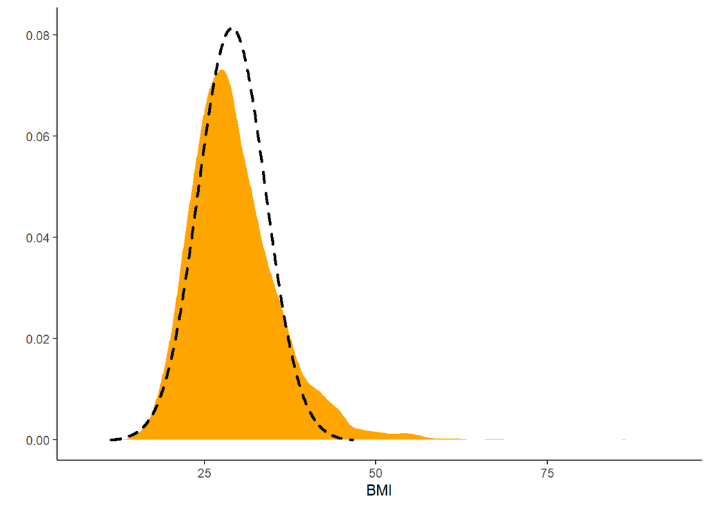

```r
prior <- distribution_normal(1024, mean = 29.0, sd = 4.73)

posterior_dist %>%
  ggplot(aes(x = x, y = y)) +
  geom_area(fill = "orange") +
  theme_classic() +
  geom_area(color = "black", fill = NA, size = 1, linetype = "dashed",
            data = estimate_density(prior, extend = TRUE)) +
  xlab("BMI") +
  ylab("")
```

From visual inspection we observe that the posterior distribution is similar to the prior distribution. However, the distributions have several differences. For example, the posterior has higher density concentrated towards the right tail of the distribution.

Support intervals are useful in this scenario for determining which intervals have gained support beyond a defined factor, $k$. The snipped of code below uses the `si` function to calculate support intervals for the posterior distribution where $k = 3$.

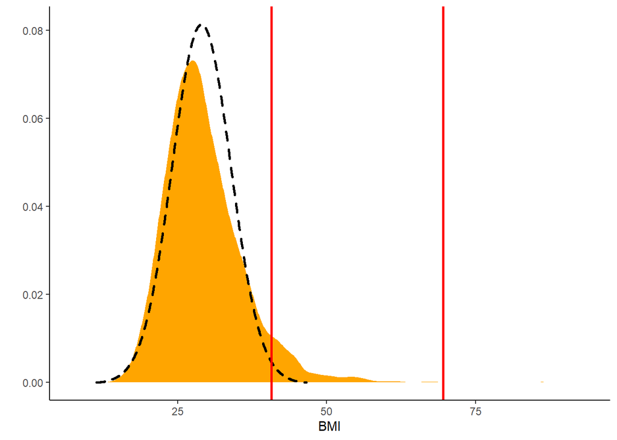

```r
si_3 <- si(posterior, prior, BF = 3)

posterior_dist %>%
  ggplot(aes(x = x, y = y)) +
  geom_area(fill = "orange") +
  theme_classic() +
  geom_area(color = "black", fill = NA, size = 1, linetype = "dashed",
            data = estimate_density(prior, extend = TRUE)) +
  # BF = 3 SI in red
  geom_vline(xintercept = si_3$CI_low, color = "red", size = 1) +
  geom_vline(xintercept = si_3$CI_high, color = "red", size = 1) +
  xlab("BMI") +
  ylab("")
```

From these results, we can see that the support interval $(40.8, 69.6)$ has received additional support for $k = 3$.

# Conclusions

In this tutorial, we have covered the concepts of both confidence and credible intervals. We showed that the less known Bayesian credible interval has a more intuitive definition than that of the frequentist confidence interval. Through examination of a CDC data set, we established a credible interval for the mean BMI of adult males in the United States. We also showed how establishing a reasonable prior distribution allows to use support intervals to make inferences about how the evidence for certain parameter values changes through observations of sample data.

# References

Block, Jason P., S. V. Subramanian, Nicholas A. Christakis, and A. James O’Malley. 2013. “Population Trends and Variation in Body Mass Index from 1971 to 2008 in the Framingham Heart Study Offspring Cohort.” *PLoS ONE* 8 (5). https://doi.org/10.1371/journal.pone.0063217.

“Confidence Intervals.” 2021. https://en.wikipedia.org/wiki/Confidence_interval.

“Credible Intervals.” 2021. https://en.wikipedia.org/wiki/Credible_interval.

“NHANES 2017-2018.” 2021. https://wwwn.cdc.gov/Nchs/Nhanes/continuousnhanes/default.aspx?BeginYear=2017.